# How Do We Know If Our Drought Definition Is Working?

A Plain-Language Guide to PCC, RMSE, and CSI

GWSC Drought Metrics Team

2026-03-24

```r
library(ggplot2)
library(dplyr)
library(tidyr)
library(patchwork)
library(scales)
```

# Background

We are developing a drought definition based on two indices — **SPI** (Standardized Precipitation Index) and **SPEI** (Standardized Precipitation-Evapotranspiration Index). A key challenge is choosing the right *threshold* — for example, should we say a drought starts when SPI drops below –0.5, –1.0, or –1.5?

To answer this, we use ERA5 climate data (2001–2023) and compare our drought definitions against **ground-level evidence** of drought stress — primarily NDVI (vegetation health from satellite) and soil moisture.

This document explains the three statistical tools we use to measure how well each threshold definition performs:

[output not shown]

# Simulated Data

> **Note:** The data below is simulated to illustrate the method. In the real analysis, ERA5 precipitation data and MODIS NDVI are used.

```r
set.seed(42)
n_months <- 276  # 23 years (2001-2023)
time      <- seq(as.Date("2001-01-01"), by = "month", length.out = n_months)

# --- Simulate ERA5-like monthly precipitation ---
seasonal   <- 50 + 40 * sin(2 * pi * (1:n_months) / 12 - pi)
precip     <- seasonal + rnorm(n_months, 0, 15)
precip     <- pmax(precip, 0)

# Inject 5 drought periods (strongly reduced precipitation)
drought_periods <- list(c(25,36), c(61,72), c(109,126), c(157,174), c(217,234))
for (dp in drought_periods) {
  precip[dp[1]:dp[2]] <- precip[dp[1]:dp[2]] * 0.40
}

# --- Calculate SPI (3-month window, simplified) ---
mu_p <- mean(precip)
sd_p <- sd(precip)
spi  <- rep(NA, n_months)
for (i in 3:n_months) {
  spi[i] <- (mean(precip[(i-2):i]) - mu_p) / sd_p
}

# --- Simulate NDVI anomaly (ground truth, lags SPI by 1 month) ---
ndvi <- rep(NA, n_months)
for (i in 2:n_months) {
  if (!is.na(spi[i-1])) ndvi[i] <- 0.65 * spi[i-1] + rnorm(1, 0, 0.35)
}

# --- Simulate Soil Moisture anomaly ---
soil_moist <- ifelse(!is.na(spi), 0.75 * spi + rnorm(n_months, 0, 0.3), NA)

# Combine into data frame
df <- data.frame(
  date       = time,
  month_idx  = 1:n_months,
  spi        = spi,
  ndvi       = ndvi,
  soil_moist = soil_moist
)

cat("Data dimensions:", nrow(df), "months x", ncol(df), "variables\n")
```

```
## Data dimensions: 276 months x 5 variables
```

```r
cat("Date range:", format(min(time)), "to", format(max(time)), "\n")
```

```
## Date range: 2001-01-01 to 2023-12-01
```

# Part 1: PCC — Did the Drought Happen at the Right Time?

## What is PCC?

**PCC (Pattern Correlation Coefficient)** measures whether two variables go up and down *together* across time.

Think of it this way: imagine two people watching the same river every month — one measures rainfall, the other checks if the fish are stressed. PCC asks: **do they both agree on which months were bad?**

- **PCC = +1.0** → Perfect agreement. Every time SPI drops, NDVI drops too.
- **PCC = 0.0** → No relationship. SPI and NDVI move independently.
- **PCC = –1.0** → Opposite patterns (rare in this context).

**What PCC does NOT tell you:** It does not care about the *size* of the difference. SPI could say “slightly dry” while NDVI says “severe stress” — PCC might still be high if they go down *at the same time*.

## Drought Event Detection Function

```r
detect_drought <- function(spi_vals, threshold, min_duration = 2) {
  # A drought starts when SPI drops below the threshold for
  # at least 'min_duration' consecutive months
  n         <- length(spi_vals)
  below_thr <- ifelse(!is.na(spi_vals) & spi_vals < threshold, 1, 0)
  drought   <- rep(0, n)
  i <- 1
  while (i <= n) {
    if (below_thr[i] == 1) {
      j <- i
      while (j <= n && below_thr[j] == 1) j <- j + 1
      if ((j - i) >= min_duration) drought[i:(j-1)] <- 1
      i <- j
    } else {
      i <- i + 1
    }
  }
  return(drought)
}

thresholds <- c(-0.5, -0.8, -1.0, -1.5, -2.0)
```

## Calculating PCC

```r
calc_pcc <- function(x, y) {
  valid <- !is.na(x) & !is.na(y)
  cor(x[valid], y[valid], method = "pearson")
}

# PCC between raw SPI and NDVI
pcc_spi_ndvi <- calc_pcc(df$spi, df$ndvi)
pcc_spi_sm   <- calc_pcc(df$spi, df$soil_moist)

# PCC between drought flag (0/1) and NDVI for each threshold
pcc_results <- data.frame(
  threshold = thresholds,
  pcc_flag_vs_ndvi = sapply(thresholds, function(thr) {
    flag <- detect_drought(df$spi, thr)
    calc_pcc(flag, df$ndvi)
  }),
  pcc_flag_vs_sm = sapply(thresholds, function(thr) {
    flag <- detect_drought(df$spi, thr)
    calc_pcc(flag, df$soil_moist)
  })
)

cat("=== PCC: Raw SPI vs Ground Truth ===\n")
```

```
## === PCC: Raw SPI vs Ground Truth ===
```

```r
cat(sprintf("SPI vs NDVI:          r = %.3f\n", pcc_spi_ndvi))
```

```
## SPI vs NDVI:          r = 0.744
```

```r
cat(sprintf("SPI vs Soil Moisture: r = %.3f\n\n", pcc_spi_sm))
```

```
## SPI vs Soil Moisture: r = 0.911
```

```r
cat("=== PCC: Drought Flag vs NDVI by Threshold ===\n")
```

```
## === PCC: Drought Flag vs NDVI by Threshold ===
```

```r
print(pcc_results)
```

```
##   threshold pcc_flag_vs_ndvi pcc_flag_vs_sm
## 1      -0.5       -0.6008506     -0.7119256
## 2      -0.8       -0.5146755     -0.5637948
## 3      -1.0       -0.3933594     -0.3885853
## 4      -1.5               NA             NA
## 5      -2.0               NA             NA
```

## Visualising PCC

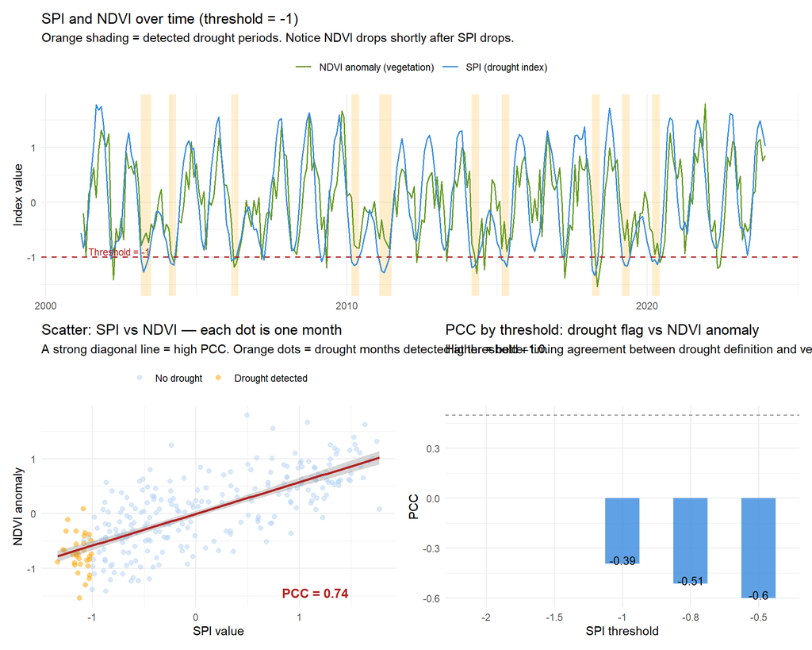

```r
# --- Plot 1: Time series of SPI and NDVI ---
thr_demo <- -1.0
df$drought_flag <- detect_drought(df$spi, thr_demo)

df_long <- df %>%
  select(date, spi, ndvi) %>%
  pivot_longer(cols = c(spi, ndvi), names_to = "variable", values_to = "value") %>%
  mutate(variable = recode(variable,
    "spi"  = "SPI (drought index)",
    "ndvi" = "NDVI anomaly (vegetation)"
  ))

drought_shading <- df %>%
  filter(drought_flag == 1) %>%
  mutate(xmin = date, xmax = date + 30)

p1 <- ggplot() +
  geom_rect(data = drought_shading,
            aes(xmin = xmin, xmax = xmax, ymin = -Inf, ymax = Inf),
            fill = "orange", alpha = 0.2) +
  geom_line(data = df_long,
            aes(x = date, y = value, colour = variable), linewidth = 0.7) +
  geom_hline(yintercept = thr_demo, linetype = "dashed",
             colour = "firebrick", linewidth = 0.7) +
  scale_colour_manual(values = c(
    "SPI (drought index)"       = "#378ADD",
    "NDVI anomaly (vegetation)" = "#639922"
  )) +
  annotate("text", x = as.Date("2001-06-01"), y = thr_demo + 0.1,
           label = paste("Threshold =", thr_demo), colour = "firebrick",
           size = 3, hjust = 0) +
  labs(
    title    = paste0("SPI and NDVI over time (threshold = ", thr_demo, ")"),
    subtitle = "Orange shading = detected drought periods. Notice NDVI drops shortly after SPI drops.",
    x = NULL, y = "Index value", colour = NULL
  ) +
  theme_minimal(base_size = 11) +
  theme(legend.position = "top")

# --- Plot 2: Scatter SPI vs NDVI ---
df_valid <- df %>% filter(!is.na(spi) & !is.na(ndvi))

p2 <- ggplot(df_valid, aes(x = spi, y = ndvi)) +
  geom_point(aes(colour = factor(drought_flag)), alpha = 0.5, size = 1.8) +
  geom_smooth(method = "lm", colour = "firebrick", se = TRUE, linewidth = 1) +
  scale_colour_manual(values = c("0" = "#B5D4F4", "1" = "orange"),
                      labels = c("0" = "No drought", "1" = "Drought detected")) +
  annotate("text", x = max(df_valid$spi, na.rm=TRUE) - 0.3,
           y = min(df_valid$ndvi, na.rm=TRUE) + 0.1,
           label = paste0("PCC = ", round(pcc_spi_ndvi, 2)),
           size = 4, colour = "firebrick", hjust = 1, fontface = "bold") +
  labs(
    title    = "Scatter: SPI vs NDVI — each dot is one month",
    subtitle = "A strong diagonal line = high PCC. Orange dots = drought months detected at threshold –1.0.",
    x = "SPI value", y = "NDVI anomaly", colour = NULL
  ) +
  theme_minimal(base_size = 11) +
  theme(legend.position = "top")

# --- Plot 3: PCC by threshold ---
p3 <- ggplot(pcc_results, aes(x = factor(threshold))) +
  geom_col(aes(y = pcc_flag_vs_ndvi), fill = "#378ADD", alpha = 0.8, width = 0.5) +
  geom_text(aes(y = pcc_flag_vs_ndvi + 0.02,
                label = round(pcc_flag_vs_ndvi, 2)), size = 3.5) +
  geom_hline(yintercept = 0.5, linetype = "dashed", colour = "gray50") +
  labs(
    title    = "PCC by threshold: drought flag vs NDVI anomaly",
    subtitle = "Higher = better timing agreement between drought definition and vegetation response.",
    x = "SPI threshold", y = "PCC"
  ) +
  theme_minimal(base_size = 11)

(p1) / (p2 + p3)
```

> **Key takeaway for non-technical readers:** PCC tells us whether our drought definition and NDVI stress go *up and down at the same time*. A PCC above 0.7 is generally considered a good match. But PCC alone is not enough — two measurements can be in sync but one could be far too large or too small. That is where RMSE comes in.

# Part 2: RMSE — Are the Numbers the Right Size?

## What is RMSE?

Imagine you correctly predict *when* it will rain (good PCC!) but you always predict 2mm when it actually rains 20mm. You have the timing right but the magnitude completely wrong.

**RMSE (Root Mean Square Error)** measures the average *size* of the difference between your drought signal and the ground truth.

- **Lower RMSE = better.** The signals match not just in timing but in size.
- **RMSE = 0** would mean perfect agreement at every time step.
- Large RMSE means your definition is either over- or under-estimating drought severity.

**Why do we square the errors first?**  
Because we want large mistakes to count more heavily than small ones. A month where we are off by 2.0 is much worse than being off by 0.2 — squaring makes that difference count.

## Calculating RMSE

```r
calc_rmse <- function(predicted, observed) {
  valid <- !is.na(predicted) & !is.na(observed)
  # Standardise both to same scale before comparing
  pred_z <- scale(predicted[valid])
  obs_z  <- scale(observed[valid])
  sqrt(mean((pred_z - obs_z)^2))
}

rmse_results <- data.frame(
  threshold      = thresholds,
  rmse_vs_ndvi   = sapply(thresholds, function(thr) {
    flag <- as.numeric(detect_drought(df$spi, thr))
    calc_rmse(flag, df$ndvi)
  }),
  rmse_vs_sm     = sapply(thresholds, function(thr) {
    flag <- as.numeric(detect_drought(df$spi, thr))
    calc_rmse(flag, df$soil_moist)
  })
)

cat("=== RMSE by Threshold (lower = better) ===\n")
```

```
## === RMSE by Threshold (lower = better) ===
```

```r
print(rmse_results)
```

```
##   threshold rmse_vs_ndvi rmse_vs_sm
## 1      -0.5     1.786050   1.846985
## 2      -0.8     1.737312   1.765269
## 3      -1.0     1.666287   1.663441
## 4      -1.5          NaN        NaN
## 5      -2.0          NaN        NaN
```

## Visualising RMSE

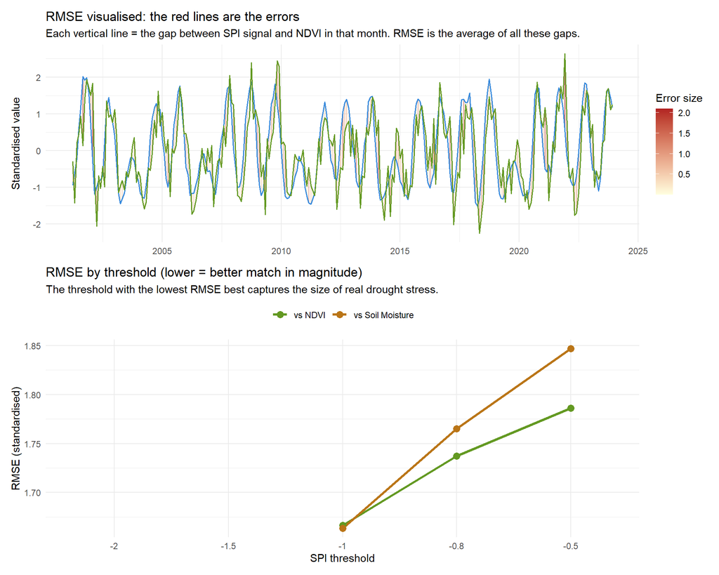

```r
# --- Plot 4: Show errors on time series ---
df_rmse <- df %>%
  filter(!is.na(spi) & !is.na(ndvi)) %>%
  mutate(
    spi_scaled  = as.numeric(scale(spi)),
    ndvi_scaled = as.numeric(scale(ndvi)),
    error       = spi_scaled - ndvi_scaled,
    abs_error   = abs(error)
  )

p4 <- ggplot(df_rmse, aes(x = date)) +
  geom_segment(aes(xend = date, y = spi_scaled, yend = ndvi_scaled,
                   colour = abs_error), alpha = 0.6, linewidth = 0.6) +
  geom_line(aes(y = spi_scaled),  colour = "#378ADD", linewidth = 0.6) +
  geom_line(aes(y = ndvi_scaled), colour = "#639922", linewidth = 0.6) +
  scale_colour_gradient(low = "lightyellow", high = "firebrick",
                        name = "Error size") +
  labs(
    title    = "RMSE visualised: the red lines are the errors",
    subtitle = "Each vertical line = the gap between SPI signal and NDVI in that month. RMSE is the average of all these gaps.",
    x = NULL, y = "Standardised value"
  ) +
  theme_minimal(base_size = 11)

# --- Plot 5: RMSE by threshold ---
rmse_long <- rmse_results %>%
  pivot_longer(cols = c(rmse_vs_ndvi, rmse_vs_sm),
               names_to = "ground_truth", values_to = "rmse") %>%
  mutate(ground_truth = recode(ground_truth,
    "rmse_vs_ndvi" = "vs NDVI",
    "rmse_vs_sm"   = "vs Soil Moisture"
  ))

p5 <- ggplot(rmse_long, aes(x = factor(threshold), y = rmse,
                              colour = ground_truth, group = ground_truth)) +
  geom_line(linewidth = 1.1) +
  geom_point(size = 3) +
  scale_colour_manual(values = c("vs NDVI" = "#639922",
                                 "vs Soil Moisture" = "#BA7517")) +
  labs(
    title    = "RMSE by threshold (lower = better match in magnitude)",
    subtitle = "The threshold with the lowest RMSE best captures the size of real drought stress.",
    x = "SPI threshold", y = "RMSE (standardised)", colour = NULL
  ) +
  theme_minimal(base_size = 11) +
  theme(legend.position = "top")

p4 / p5
```

> **Key takeaway for non-technical readers:** Think of RMSE like the average distance between two friends walking side by side. PCC checks they are walking in the same direction — RMSE checks how far apart they are. You want both to be good: same direction AND walking close together.

# Part 3: CSI — Did We Catch the Real Droughts?

## What is CSI?

Even if PCC and RMSE are good, there is one more thing to check: **did our definition actually detect the real drought events?**

To answer this, we compare our detected drought months against a ground-truth drought label (months where both NDVI and soil moisture were below normal). Every month falls into one of four categories:

|  | Ground truth = drought | Ground truth = no drought |
| --- | --- | --- |
| **We detected drought** | ✅ Hit | ❌ False Alarm |
| **We detected no drought** | ❌ Miss | ✅ Correct Rejection |

From this table we calculate three scores:

- **POD (Probability of Detection)** = Hits / (Hits + Misses) → *Did we catch the real droughts?*
- **FAR (False Alarm Ratio)** = False Alarms / (Hits + False Alarms) → *How often did we cry wolf?*
- **CSI (Critical Success Index)** = Hits / (Hits + Misses + False Alarms) → *Overall skill, penalising both misses and false alarms.*

**CSI is the most important of the three** because it balances both types of error. A perfect CSI = 1.0, a useless definition = 0.

## Calculating CSI

```r
# Ground truth: a month is a real drought if BOTH NDVI and soil moisture
# are below –0.5 standard deviations
df$ground_truth <- as.integer(
  !is.na(df$ndvi) & df$ndvi < -0.5 &
  !is.na(df$soil_moist) & df$soil_moist < -0.5
)

cat("Total months classified as ground-truth drought:",
    sum(df$ground_truth), "out of", n_months, "\n\n")
```

```
## Total months classified as ground-truth drought: 39 out of 276
```

```r
csi_results <- lapply(thresholds, function(thr) {
  detected <- detect_drought(df$spi, thr)
  gt       <- df$ground_truth

  hits    <- sum(detected == 1 & gt == 1, na.rm = TRUE)
  misses  <- sum(detected == 0 & gt == 1, na.rm = TRUE)
  fa      <- sum(detected == 1 & gt == 0, na.rm = TRUE)
  cr      <- sum(detected == 0 & gt == 0, na.rm = TRUE)

  data.frame(
    threshold = thr,
    hits      = hits,
    misses    = misses,
    false_alarms = fa,
    correct_rejections = cr,
    POD = round(hits / (hits + misses), 3),
    FAR = round(fa   / (hits + fa),     3),
    CSI = round(hits / (hits + misses + fa), 3)
  )
}) %>% bind_rows()

cat("=== Contingency Table Results ===\n")
```

```
## === Contingency Table Results ===
```

```r
print(csi_results)
```

```
##   threshold hits misses false_alarms correct_rejections   POD   FAR   CSI
## 1      -0.5   36      3           65                172 0.923 0.644 0.346
## 2      -0.8   31      8           27                210 0.795 0.466 0.470
## 3      -1.0   19     20           14                223 0.487 0.424 0.358
## 4      -1.5    0     39            0                237 0.000   NaN 0.000
## 5      -2.0    0     39            0                237 0.000   NaN 0.000
```

```r
best_thr <- csi_results$threshold[which.max(csi_results$CSI)]
cat(sprintf("\nBest threshold by CSI: %.1f (CSI = %.3f)\n",
            best_thr, max(csi_results$CSI)))
```

```
##
## Best threshold by CSI: -0.8 (CSI = 0.470)
```

## Visualising CSI

[figure not shown]

```r
# --- Plot 6: Contingency table for best threshold ---
best_row <- csi_results %>% filter(threshold == best_thr)

ct_df <- data.frame(
  x     = c(1, 2, 1, 2),
  y     = c(2, 2, 1, 1),
  label = c(
    paste0("HITS\n", best_row$hits, " months"),
    paste0("FALSE ALARMS\n", best_row$false_alarms, " months"),
    paste0("MISSES\n", best_row$misses, " months"),
    paste0("CORRECT\nREJECTIONS\n", best_row$correct_rejections, " months")
  ),
  fill  = c("#EAF3DE", "#FCEBEB", "#FCEBEB", "#F1EFE8"),
  tcol  = c("#3B6D11", "#A32D2D", "#A32D2D", "#5F5E5A")
)

p6 <- ggplot(ct_df, aes(x, y)) +
  geom_tile(aes(fill = fill), colour = "white", linewidth = 1.5, width = 0.95, height = 0.95) +
  geom_text(aes(label = label, colour = tcol), size = 3.5, fontface = "bold", lineheight = 1.3) +
  scale_fill_identity() +
  scale_colour_identity() +
  annotate("text", x = 1, y = 2.6, label = "Ground truth = DROUGHT",
           size = 3.5, colour = "gray40", fontface = "italic") +
  annotate("text", x = 2, y = 2.6, label = "Ground truth = NO drought",
           size = 3.5, colour = "gray40", fontface = "italic") +
  annotate("text", x = 0.35, y = 2, label = "We said\nDROUGHT",
           size = 3.5, colour = "gray40", fontface = "italic", angle = 90) +
  annotate("text", x = 0.35, y = 1, label = "We said\nNO drought",
           size = 3.5, colour = "gray40", fontface = "italic", angle = 90) +
  scale_x_continuous(limits = c(0.3, 2.5)) +
  scale_y_continuous(limits = c(0.4, 2.8)) +
  labs(
    title    = paste0("Contingency table for best threshold (", best_thr, ")"),
    subtitle = paste0("POD = ", best_row$POD,
                      " | FAR = ", best_row$FAR,
                      " | CSI = ", best_row$CSI)
  ) +
  theme_void(base_size = 11) +
  theme(plot.title = element_text(face = "bold", size = 12),
        plot.subtitle = element_text(colour = "gray40"))

# --- Plot 7: POD, FAR, CSI by threshold ---
skill_long <- csi_results %>%
  select(threshold, POD, FAR, CSI) %>%
  pivot_longer(-threshold, names_to = "metric", values_to = "value")

p7 <- ggplot(skill_long, aes(x = factor(threshold), y = value,
                               colour = metric, group = metric)) +
  geom_line(linewidth = 1.2) +
  geom_point(size = 3.5) +
  geom_vline(xintercept = which(thresholds == best_thr),
             linetype = "dashed", colour = "gray50", linewidth = 0.8) +
  annotate("text",
           x     = which(thresholds == best_thr) + 0.15,
           y     = 0.15,
           label = paste("Best threshold\n(highest CSI)"),
           size  = 3, colour = "gray40", hjust = 0) +
  scale_colour_manual(values = c(POD = "#378ADD", FAR = "#E24B4A",
                                 CSI = "#639922")) +
  labs(
    title    = "Skill scores by threshold",
    subtitle = "Want: high POD (catch real droughts), low FAR (few false alarms), high CSI (overall skill).",
    x = "SPI threshold", y = "Score (0 to 1)", colour = "Metric"
  ) +
  theme_minimal(base_size = 11) +
  theme(legend.position = "top")

# --- Plot 8: Visual of detected vs missed droughts on time series ---
df$detected_best <- detect_drought(df$spi, best_thr)
df$event_type    <- case_when(
  df$detected_best == 1 & df$ground_truth == 1 ~ "Hit",
  df$detected_best == 1 & df$ground_truth == 0 ~ "False Alarm",
  df$detected_best == 0 & df$ground_truth == 1 ~ "Miss",
  TRUE                                          ~ "Correct Rejection"
)

event_pal <- c(
  "Hit"               = "#639922",
  "False Alarm"       = "#E24B4A",
  "Miss"              = "#BA7517",
  "Correct Rejection" = "gray85"
)

p8 <- ggplot(df, aes(x = date, y = 1, fill = event_type)) +
  geom_tile(height = 1) +
  scale_fill_manual(values = event_pal) +
  labs(
    title    = "Month-by-month classification across full time series",
    subtitle = "Green = correctly detected drought | Red = false alarm | Orange = missed drought",
    x = NULL, y = NULL, fill = NULL
  ) +
  theme_minimal(base_size = 11) +
  theme(axis.text.y = element_blank(),
        axis.ticks.y = element_blank(),
        legend.position = "top",
        panel.grid = element_blank())

(p6 + p7) / p8 +
  plot_layout(heights = c(2, 1))
```

> **Key takeaway for non-technical readers:** Think of CSI like a smoke detector test. POD asks: “Did it go off during every real fire?” FAR asks: “How often did it give false alarms?” CSI combines both — a great smoke detector catches real fires AND doesn’t go off every time someone makes toast.

# Part 4: Putting It All Together

```r
# Combine all metrics into one summary table
summary_table <- csi_results %>%
  left_join(pcc_results, by = "threshold") %>%
  left_join(rmse_results, by = "threshold") %>%
  select(threshold, pcc_flag_vs_ndvi, rmse_vs_ndvi, POD, FAR, CSI) %>%
  rename(
    Threshold = threshold,
    PCC       = pcc_flag_vs_ndvi,
    RMSE      = rmse_vs_ndvi
  )

print(summary_table)
```

```
##   Threshold        PCC     RMSE   POD   FAR   CSI
## 1      -0.5 -0.6008506 1.786050 0.923 0.644 0.346
## 2      -0.8 -0.5146755 1.737312 0.795 0.466 0.470
## 3      -1.0 -0.3933594 1.666287 0.487 0.424 0.358
## 4      -1.5         NA      NaN 0.000   NaN 0.000
## 5      -2.0         NA      NaN 0.000   NaN 0.000
```

[figure not shown]

```r
# Normalise metrics for radar/summary plot (RMSE inverted — lower is better)
summary_norm <- summary_table %>%
  mutate(
    PCC_norm  = (PCC  - min(PCC))  / (max(PCC)  - min(PCC)),
    RMSE_norm = 1 - (RMSE - min(RMSE)) / (max(RMSE) - min(RMSE)), # inverted
    CSI_norm  = (CSI  - min(CSI))  / (max(CSI)  - min(CSI)),
    POD_norm  = (POD  - min(POD))  / (max(POD)  - min(POD))
  ) %>%
  mutate(
    overall_score = (PCC_norm + RMSE_norm + CSI_norm + POD_norm) / 4
  )

p_final <- ggplot(summary_norm,
                  aes(x = factor(Threshold), y = overall_score)) +
  geom_col(aes(fill = overall_score), width = 0.6, show.legend = FALSE) +
  geom_text(aes(label = paste0("CSI=", CSI, "\nPCC=", round(PCC, 2))),
            vjust = -0.3, size = 3.2, lineheight = 1.2) +
  scale_fill_gradient(low = "#B5D4F4", high = "#185FA5") +
  geom_vline(xintercept = which(thresholds == best_thr),
             linetype = "dashed", colour = "firebrick", linewidth = 1) +
  labs(
    title    = "Overall performance score by threshold (combines PCC, RMSE, CSI, POD)",
    subtitle = paste0("Best threshold = ", best_thr,
                      " | Highest combined score across all four metrics"),
    x = "SPI threshold", y = "Combined score (normalised)"
  ) +
  theme_minimal(base_size = 12)

p_final
```

## Summary Table

| Metric | What it measures | Good value | Bad value |
| --- | --- | --- | --- |
| **PCC** | Timing/direction agreement with NDVI | Close to 1.0 | Close to 0 |
| **RMSE** | Magnitude of errors | As low as possible | High values |
| **POD** | Did we catch real droughts? | Close to 1.0 | Close to 0 |
| **FAR** | How often did we cry wolf? | Close to 0 | Close to 1.0 |
| **CSI** | Overall detection skill | Close to 1.0 | Close to 0 |

*Analysis prepared using R. Data is simulated for illustrative purposes.* *Real analysis will use ERA5 (2001–2023) and MODIS NDVI/soil moisture.*